# Predicting 2019 CFB Games

2022-08-22

# What is this?

This page displays predictions for games in the 2019 CFB season. These predictions come from a model built on historical college football play by play and game data in order to simulate upcoming games. All data is from collegefootballdata.com.

# 1 Week 13 Predictions

| Season | Week | Quality | Home | Away | Pr(HomeWin) | Prediction | Result | Correct | correct |
| --- | --- | --- | --- | --- | --- | --- | --- | --- | --- |
| 2019 | 13 | 90 | Ohio State | Penn State | 0.736 | Ohio State by 11 |  |  |  |
| 2019 | 13 | 84 | Georgia | Texas A&M | 0.821 | Georgia by 16 |  |  |  |
| 2019 | 13 | 69 | Oklahoma | TCU | 0.895 | Oklahoma by 21 |  |  |  |
| 2019 | 13 | 68 | Baylor | Texas | 0.640 | Baylor by 4.5 |  |  |  |
| 2019 | 13 | 68 | Indiana | Michigan | 0.309 | Michigan by 9 |  |  |  |
| 2019 | 13 | 64 | Notre Dame | Boston College | 0.886 | Notre Dame by 19 |  |  |  |
| 2019 | 13 | 63 | Arizona State | Oregon | 0.241 | Oregon by 13 |  |  |  |
| 2019 | 13 | 61 | Virginia Tech | Pittsburgh | 0.600 | Virginia Tech by 4 |  |  |  |
| 2019 | 13 | 61 | Cincinnati | Temple | 0.800 | Cincinnati by 14 |  |  |  |
| 2019 | 13 | 58 | Iowa | Illinois | 0.830 | Iowa by 16 |  |  |  |

[output cut: 54 more lines]

# 2 Results Through Week 12

How has the model performed so far in 2019?

## 2.1 Assessment

The model predicts the probability that the home team will win and their expected margin of victory (or defeat). I assess the model’s performance by assessing the accuracy of its predictions (win/loss), the logloss of its probabilities, and the mean absolute error of the margin.

| Season | Week | N | Outcome Accuracy | Outcome LogLoss | Margin MAE |
| --- | --- | --- | --- | --- | --- |
| 2019 | 1 | 85 | 0.91 | 0.31 | 11.8 |
| 2019 | 2 | 74 | 0.84 | 0.35 | 13.9 |
| 2019 | 3 | 68 | 0.82 | 0.41 | 15.2 |
| 2019 | 4 | 58 | 0.76 | 0.47 | 12.1 |
| 2019 | 5 | 55 | 0.84 | 0.40 | 13.7 |
| 2019 | 6 | 48 | 0.69 | 0.58 | 12.2 |
| 2019 | 7 | 53 | 0.68 | 0.60 | 13.1 |
| 2019 | 8 | 62 | 0.71 | 0.54 | 13.2 |
| 2019 | 9 | 55 | 0.69 | 0.59 | 14.4 |
| 2019 | 10 | 48 | 0.75 | 0.47 | 14.1 |
| 2019 | 11 | 48 | 0.60 | 0.58 | 13.6 |
| 2019 | 12 | 55 | 0.84 | 0.45 | 11.5 |
| Season Average: |  |  | 0.77 | 0.47 | 13.2 |

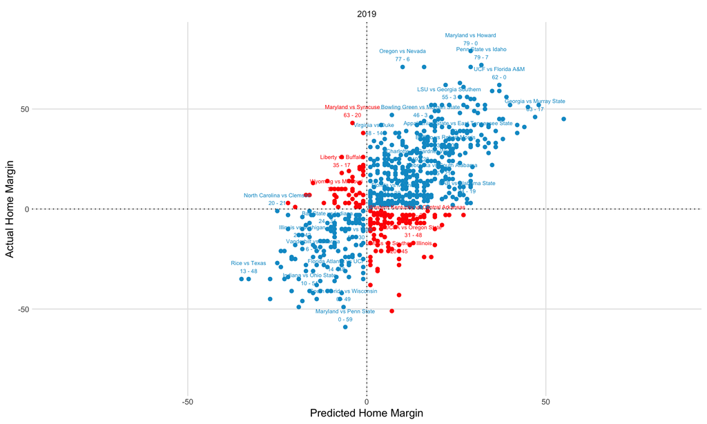

## 2.2 Results

The following table shows the results of games played in previous weeks next to the model’s predictions.

| Season | Week | Quality | Home | Away | Pr(HomeWin) | Prediction | Result | Correct | correct |
| --- | --- | --- | --- | --- | --- | --- | --- | --- | --- |
| 2019 | 12 | 86 | Auburn | Georgia | 0.448 | Georgia by 3 | Georgia by 7 | Yes | 1 |
| 2019 | 12 | 78 | Baylor | Oklahoma | 0.450 | Oklahoma by 3 | Oklahoma by 3 | Yes | 1 |
| 2019 | 12 | 76 | Mississippi State | Alabama | 0.125 | Alabama by 17 | Alabama by 31 | Yes | 1 |
| 2019 | 12 | 76 | Clemson | Wake Forest | 0.949 | Clemson by 30 | Clemson by 49 | Yes | 1 |
| 2019 | 12 | 70 | Iowa | Minnesota | 0.536 | Iowa by 1 | Iowa by 4 | Yes | 1 |
| 2019 | 12 | 69 | Penn State | Indiana | 0.858 | Penn State by 17 | Penn State by 7 | Yes | 1 |
| 2019 | 12 | 69 | Ole Miss | LSU | 0.085 | LSU by 24 | LSU by 21 | Yes | 1 |
| 2019 | 12 | 67 | Missouri | Florida | 0.299 | Florida by 9 | Florida by 17 | Yes | 1 |
| 2019 | 12 | 67 | Iowa State | Texas | 0.557 | Iowa State by 2 | Iowa State by 2 | Yes | 1 |
| 2019 | 12 | 65 | Michigan | Michigan State | 0.865 | Michigan by 19 | Michigan by 34 | Yes | 1 |

[output cut: 699 more lines]

# 3 Predicting the Rest of the Season

For example, we simulate the entire season before any games are played by simulating week two based on the (simulated) results of week one, then simulating week three based on the (simulated) results from week two. As a result, predictions for future weeks tend to be less accurate than predictions made one week in advance and are likely to change as we get closer to the actual game.

| Season | Week | Quality | Home | Away | Pr(HomeWin) | Prediction | Result | Correct | correct |
| --- | --- | --- | --- | --- | --- | --- | --- | --- | --- |
| 2019 | 13 | 90 | Ohio State | Penn State | 0.736 | Ohio State by 11 |  |  |  |
| 2019 | 13 | 84 | Georgia | Texas A&M | 0.821 | Georgia by 16 |  |  |  |
| 2019 | 13 | 69 | Oklahoma | TCU | 0.895 | Oklahoma by 21 |  |  |  |
| 2019 | 13 | 68 | Baylor | Texas | 0.640 | Baylor by 4.5 |  |  |  |
| 2019 | 13 | 68 | Indiana | Michigan | 0.309 | Michigan by 9 |  |  |  |
| 2019 | 13 | 64 | Notre Dame | Boston College | 0.886 | Notre Dame by 19 |  |  |  |
| 2019 | 13 | 63 | Arizona State | Oregon | 0.241 | Oregon by 13 |  |  |  |
| 2019 | 13 | 61 | Virginia Tech | Pittsburgh | 0.600 | Virginia Tech by 4 |  |  |  |
| 2019 | 13 | 61 | Cincinnati | Temple | 0.800 | Cincinnati by 14 |  |  |  |
| 2019 | 13 | 58 | Iowa | Illinois | 0.830 | Iowa by 16 |  |  |  |

[output cut: 122 more lines]